# Quality Prediction of Red Wines

Kiseong Park; Doctor, Data scientist

Wednesday, April 17, 2019

Today I am going to analyze the [‘winequality-red’](http://archive.ics.uci.edu/ml/datasets/Wine+Quality), as I said yesterday.  
The goal of analysis is same to [Quality Prediction of Wines](https://github.com/elmidion/wines/blob/master/wines.Rmd).  
It is to predict the quality of red wines.

Let’s see the red-wines data.  
This data is seperated by semicolon. So when I load this data, I used `sep=';'`.

```r
glimpse(rwines)
```

```
Observations: 1,599
Variables: 12
$ fixed.acidity        <dbl> 7.4, 7.8, 7.8, 11.2, 7.4, 7.4, 7.9, 7.3, 7.8, 7.5, 6.7, 7.5, 5.6, 7.8, 8.9,...
$ volatile.acidity     <dbl> 0.700, 0.880, 0.760, 0.280, 0.700, 0.660, 0.600, 0.650, 0.580, 0.500, 0.580...
$ citric.acid          <dbl> 0.00, 0.00, 0.04, 0.56, 0.00, 0.00, 0.06, 0.00, 0.02, 0.36, 0.08, 0.36, 0.0...
$ residual.sugar       <dbl> 1.9, 2.6, 2.3, 1.9, 1.9, 1.8, 1.6, 1.2, 2.0, 6.1, 1.8, 6.1, 1.6, 1.6, 3.8, ...
$ chlorides            <dbl> 0.076, 0.098, 0.092, 0.075, 0.076, 0.075, 0.069, 0.065, 0.073, 0.071, 0.097...
$ free.sulfur.dioxide  <dbl> 11, 25, 15, 17, 11, 13, 15, 15, 9, 17, 15, 17, 16, 9, 52, 51, 35, 16, 6, 17...
$ total.sulfur.dioxide <dbl> 34, 67, 54, 60, 34, 40, 59, 21, 18, 102, 65, 102, 59, 29, 145, 148, 103, 56...
$ density              <dbl> 0.9978, 0.9968, 0.9970, 0.9980, 0.9978, 0.9978, 0.9964, 0.9946, 0.9968, 0.9...
$ pH                   <dbl> 3.51, 3.20, 3.26, 3.16, 3.51, 3.51, 3.30, 3.39, 3.36, 3.35, 3.28, 3.35, 3.5...
$ sulphates            <dbl> 0.56, 0.68, 0.65, 0.58, 0.56, 0.56, 0.46, 0.47, 0.57, 0.80, 0.54, 0.80, 0.5...
$ alcohol              <dbl> 9.4, 9.8, 9.8, 9.8, 9.4, 9.4, 9.4, 10.0, 9.5, 10.5, 9.2, 10.5, 9.9, 9.1, 9....
$ quality              <int> 5, 5, 5, 6, 5, 5, 5, 7, 7, 5, 5, 5, 5, 5, 5, 5, 7, 5, 4, 6, 6, 5, 5, 5, 6, ...
```

The data has 1599 observations, 11 independant variables and 1 dependant variable.

```r
summary(rwines)
```

```
 fixed.acidity   volatile.acidity  citric.acid    residual.sugar     chlorides       free.sulfur.dioxide
 Min.   : 4.60   Min.   :0.1200   Min.   :0.000   Min.   : 0.900   Min.   :0.01200   Min.   : 1.00
 1st Qu.: 7.10   1st Qu.:0.3900   1st Qu.:0.090   1st Qu.: 1.900   1st Qu.:0.07000   1st Qu.: 7.00
 Median : 7.90   Median :0.5200   Median :0.260   Median : 2.200   Median :0.07900   Median :14.00
 Mean   : 8.32   Mean   :0.5278   Mean   :0.271   Mean   : 2.539   Mean   :0.08747   Mean   :15.87
 3rd Qu.: 9.20   3rd Qu.:0.6400   3rd Qu.:0.420   3rd Qu.: 2.600   3rd Qu.:0.09000   3rd Qu.:21.00
 Max.   :15.90   Max.   :1.5800   Max.   :1.000   Max.   :15.500   Max.   :0.61100   Max.   :72.00
 total.sulfur.dioxide    density             pH          sulphates         alcohol         quality
 Min.   :  6.00       Min.   :0.9901   Min.   :2.740   Min.   :0.3300   Min.   : 8.40   Min.   :3.000
 1st Qu.: 22.00       1st Qu.:0.9956   1st Qu.:3.210   1st Qu.:0.5500   1st Qu.: 9.50   1st Qu.:5.000
 Median : 38.00       Median :0.9968   Median :3.310   Median :0.6200   Median :10.20   Median :6.000
 Mean   : 46.47       Mean   :0.9967   Mean   :3.311   Mean   :0.6581   Mean   :10.42   Mean   :5.636
 3rd Qu.: 62.00       3rd Qu.:0.9978   3rd Qu.:3.400   3rd Qu.:0.7300   3rd Qu.:11.10   3rd Qu.:6.000
 Max.   :289.00       Max.   :1.0037   Max.   :4.010   Max.   :2.0000   Max.   :14.90   Max.   :8.000
```

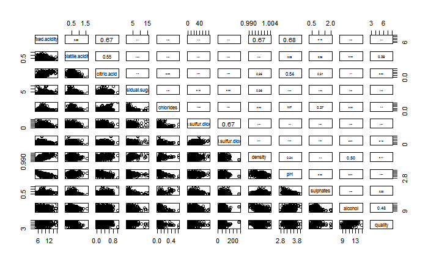

```r
pairs(rwines, upper.panel = panel.cor)
```

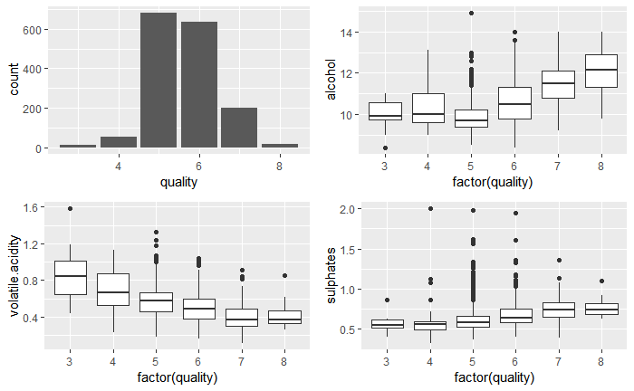

```r
library(gridExtra)
p1 <- ggplot(rwines, aes(quality)) + geom_bar()
p2 <- ggplot(rwines, aes(factor(quality), alcohol)) + geom_boxplot()
p3 <- ggplot(rwines, aes(factor(quality), volatile.acidity)) + geom_boxplot()
p4 <- ggplot(rwines, aes(factor(quality), sulphates)) + geom_boxplot()
grid.arrange(p1, p2, p3, p4, ncol=2)
```

`Alcohol` has a strong positive correlation with `quality`, but it doesn’t seems to be a linear correlation.  
`volatile.acidity` has a negative correlation with `quality`.  
`sulphates` show weak positive correlation with `quality`.

## Splitting data into training, validation, and test sets

```r
set.seed(0417)
n <- nrow(rwines)
idx <- 1:n
training_idx <- sample(idx, n*0.6)
validation_idx <- setdiff(idx, training_idx)
test_idx <- sample(validation_idx, n*0.2)
validation_idx <- setdiff(validation_idx, test_idx)
training <- rwines[training_idx,]
validation <- rwines[validation_idx,]
test <- rwines[test_idx,]
y_obs <- validation$quality
data.frame(nrow(training), nrow(validation), nrow(test))
```

| nrow.training. | nrow.validation. | nrow.test. |
| --- | --- | --- |
| 959 | 321 | 319 |

To train, validate, and test models, I splitted data into 3 groups: training, validation, and test sets.  
The training set has 959 observations extracted from data by random sampling.  
The validation set has other 321 observations.  
The test set has 319 observations that differ from training and validation sets.

## Linear Regression Model

```r
rw_lm <- lm(quality ~ ., training)
rw_lm %>% summary()
```

```
Call:
lm(formula = quality ~ ., data = training)

Residuals:
     Min       1Q   Median       3Q      Max
-2.71022 -0.36524 -0.05337  0.43341  2.03764

Coefficients:
                       Estimate Std. Error t value Pr(>|t|)
(Intercept)           1.816e+01  2.672e+01   0.680 0.496782
fixed.acidity        -5.397e-03  3.290e-02  -0.164 0.869764
volatile.acidity     -9.729e-01  1.592e-01  -6.112 1.44e-09 ***
citric.acid          -9.229e-02  1.909e-01  -0.484 0.628847
residual.sugar       -2.455e-03  1.908e-02  -0.129 0.897653
chlorides            -1.166e+00  5.062e-01  -2.304 0.021461 *
free.sulfur.dioxide   6.719e-03  2.705e-03   2.484 0.013178 *
total.sulfur.dioxide -3.522e-03  9.055e-04  -3.889 0.000108 ***
density              -1.363e+01  2.730e+01  -0.499 0.617669
pH                   -5.436e-01  2.477e-01  -2.195 0.028436 *
sulphates             8.595e-01  1.445e-01   5.947 3.84e-09 ***
alcohol               2.918e-01  3.425e-02   8.519  < 2e-16 ***
---
Signif. codes:  0 ‘***’ 0.001 ‘**’ 0.01 ‘*’ 0.05 ‘.’ 0.1 ‘ ’ 1

Residual standard error: 0.6312 on 947 degrees of freedom
Multiple R-squared:  0.3481,    Adjusted R-squared:  0.3405
F-statistic: 45.97 on 11 and 947 DF,  p-value: < 2.2e-16
```

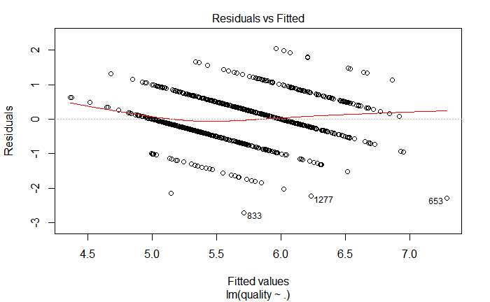

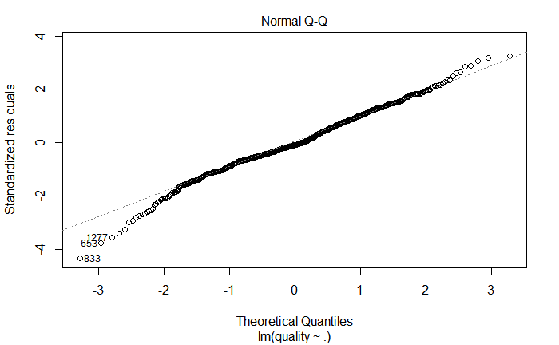

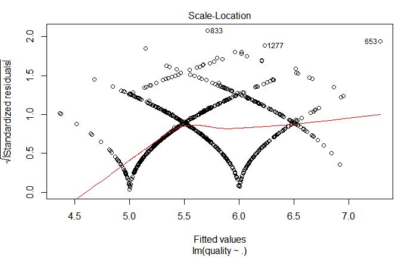

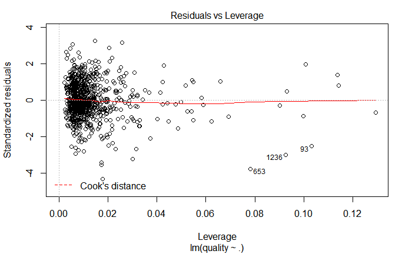

```r
rw_lm %>% plot()
```

```r
yhat_lm <- predict(rw_lm, newdata = validation)
RMSE_lm <- rmse(y_obs, yhat_lm)
df_LM <- data.frame(Method = 'LM', RMSE = RMSE_lm)
df_LM
```

| Method | RMSE |
| --- | --- |
| LM | 0.6624028 |

First, I assigned a linear regression model.  
In ‘Residuals vs Fitted values’ plot, the means of residuals is not linear.  
It seems to have quadratic correlation.  
I am going to assign a quadratic regression model.

```r
rw_lm2 <- lm(quality ~ .^2, training)
rw_lm2 %>% summary()
```

```
Call:
lm(formula = quality ~ .^2, data = training)

Residuals:
     Min       1Q   Median       3Q      Max
-2.22742 -0.34491 -0.07415  0.39211  1.95510

Coefficients:
                                           Estimate Std. Error t value Pr(>|t|)
(Intercept)                               1.985e+02  7.194e+02   0.276 0.782642
fixed.acidity                            -4.338e+00  1.365e+01  -0.318 0.750701
volatile.acidity                          2.556e+02  2.133e+02   1.198 0.231167
citric.acid                               7.241e+00  2.164e+02   0.033 0.973318
residual.sugar                           -4.227e-01  1.494e+01  -0.028 0.977432
chlorides                                -9.404e+02  8.482e+02  -1.109 0.267860
free.sulfur.dioxide                      -5.004e+00  3.747e+00  -1.336 0.182050
total.sulfur.dioxide                      2.145e+00  1.270e+00   1.690 0.091453 .
density                                  -2.051e+02  7.216e+02  -0.284 0.776334
pH                                       -7.567e+01  1.926e+02  -0.393 0.694541
sulphates                                 1.132e+02  2.157e+02   0.525 0.599679
alcohol                                  -3.631e+00  1.648e+01  -0.220 0.825627
fixed.acidity:volatile.acidity           -6.358e-02  2.616e-01  -0.243 0.808034
fixed.acidity:citric.acid                -3.586e-01  2.437e-01  -1.471 0.141533
fixed.acidity:residual.sugar              1.618e-02  2.440e-02   0.663 0.507411
fixed.acidity:chlorides                  -1.647e+00  7.435e-01  -2.215 0.027026 *
fixed.acidity:free.sulfur.dioxide        -6.460e-03  4.230e-03  -1.527 0.127045
fixed.acidity:total.sulfur.dioxide        2.014e-03  1.611e-03   1.251 0.211398
fixed.acidity:density                     3.874e+00  1.353e+01   0.286 0.774738
fixed.acidity:pH                          3.213e-01  1.524e-01   2.108 0.035331 *
fixed.acidity:sulphates                   1.736e-01  2.388e-01   0.727 0.467340
fixed.acidity:alcohol                    -4.259e-02  3.063e-02  -1.390 0.164731
volatile.acidity:citric.acid             -4.987e-01  1.044e+00  -0.478 0.633063
volatile.acidity:residual.sugar          -4.730e-02  1.775e-01  -0.267 0.789905
volatile.acidity:chlorides                4.760e+00  4.078e+00   1.167 0.243504
volatile.acidity:free.sulfur.dioxide     -1.829e-02  2.298e-02  -0.796 0.426331
volatile.acidity:total.sulfur.dioxide     1.765e-02  6.681e-03   2.641 0.008399 **
volatile.acidity:density                 -2.519e+02  2.178e+02  -1.157 0.247616
volatile.acidity:pH                      -1.759e+00  1.949e+00  -0.902 0.367046
volatile.acidity:sulphates                7.622e-02  1.208e+00   0.063 0.949714
volatile.acidity:alcohol                  1.318e-02  2.744e-01   0.048 0.961696
```

[output cut: 27 more lines]

```
total.sulfur.dioxide:pH                   1.686e-02  1.087e-02   1.551 0.121226
total.sulfur.dioxide:sulphates            3.468e-03  7.380e-03   0.470 0.638504
total.sulfur.dioxide:alcohol             -3.667e-03  1.795e-03  -2.043 0.041393 *
density:pH                                7.766e+01  1.927e+02   0.403 0.687117
density:sulphates                        -1.233e+02  2.186e+02  -0.564 0.572681
density:alcohol                           5.195e+00  1.694e+01   0.307 0.759219
pH:sulphates                              1.782e+00  1.752e+00   1.017 0.309337
pH:alcohol                               -3.365e-01  2.788e-01  -1.207 0.227646
sulphates:alcohol                         3.812e-01  2.661e-01   1.432 0.152388
---
Signif. codes:  0 ‘***’ 0.001 ‘**’ 0.01 ‘*’ 0.05 ‘.’ 0.1 ‘ ’ 1

Residual standard error: 0.6059 on 892 degrees of freedom
Multiple R-squared:  0.4343,    Adjusted R-squared:  0.3924
F-statistic: 10.37 on 66 and 892 DF,  p-value: < 2.2e-16
```

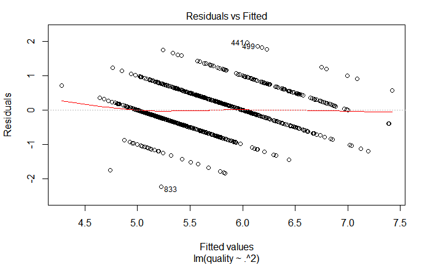

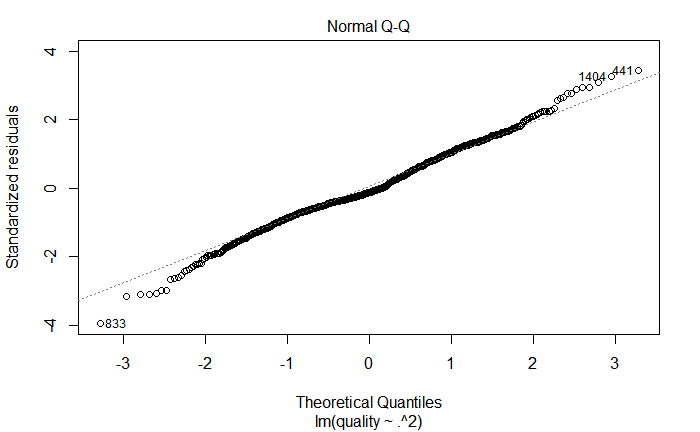

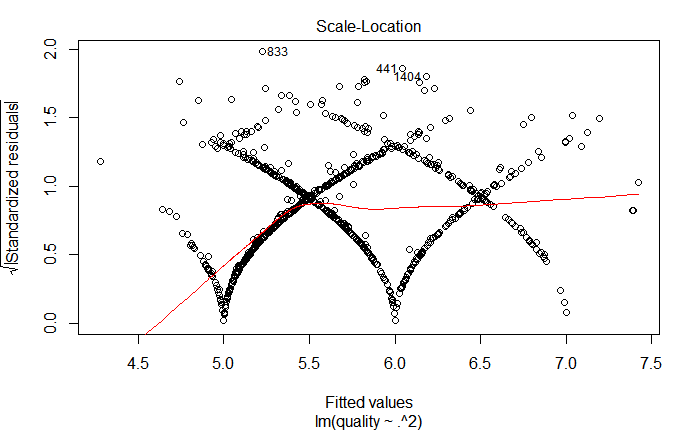

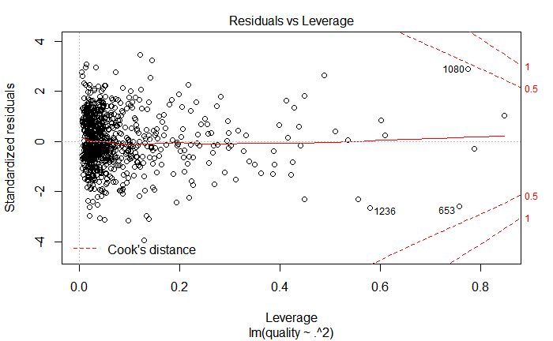

```r
rw_lm2 %>% plot()
```

```r
yhat_lm2 <- predict(rw_lm2, validation)
RMSE_lm2 <- rmse(y_obs, yhat_lm2)
df_LM2 <- data.frame(Method = 'LM2', RMSE = RMSE_lm2)
df_LM2
```

| Method | RMSE |
| --- | --- |
| LM2 | 0.6645706 |

There are too many features in regression equation.  
Now I am going to assign stepwise method.

```r
library(MASS)
rw_step <- stepAIC(rw_lm, scope=list(upper = ~.^2, lower = ~ 1))
```

```r
rw_step %>% summary()
```

```
Call:
lm(formula = quality ~ fixed.acidity + volatile.acidity + citric.acid +
    residual.sugar + chlorides + free.sulfur.dioxide + total.sulfur.dioxide +
    pH + sulphates + alcohol + total.sulfur.dioxide:sulphates +
    residual.sugar:alcohol + sulphates:alcohol + fixed.acidity:chlorides +
    free.sulfur.dioxide:alcohol + fixed.acidity:pH + citric.acid:pH +
    volatile.acidity:total.sulfur.dioxide + volatile.acidity:residual.sugar +
    chlorides:free.sulfur.dioxide + fixed.acidity:citric.acid +
    volatile.acidity:chlorides + fixed.acidity:volatile.acidity,
    data = training)

Residuals:
     Min       1Q   Median       3Q      Max
-2.30293 -0.34869 -0.09109  0.42222  1.85937

Coefficients:
                                       Estimate Std. Error t value Pr(>|t|)
(Intercept)                            8.925274   2.824605   3.160 0.001629 **
fixed.acidity                         -0.686235   0.352409  -1.947 0.051802 .
volatile.acidity                      -0.211193   0.830536  -0.254 0.799332
citric.acid                           16.656226   4.102711   4.060 5.32e-05 ***
residual.sugar                         0.754851   0.154814   4.876 1.27e-06 ***
chlorides                              4.838187   3.848401   1.257 0.208997
free.sulfur.dioxide                   -0.037852   0.023531  -1.609 0.108033
total.sulfur.dioxide                  -0.004173   0.003012  -1.385 0.166269
pH                                    -1.777052   0.729646  -2.435 0.015057 *
sulphates                             -3.813003   1.432248  -2.662 0.007895 **
alcohol                                0.061560   0.100884   0.610 0.541874
total.sulfur.dioxide:sulphates        -0.008288   0.002930  -2.828 0.004781 **
residual.sugar:alcohol                -0.062057   0.013025  -4.764 2.20e-06 ***
sulphates:alcohol                      0.503012   0.134311   3.745 0.000191 ***
fixed.acidity:chlorides               -0.862881   0.413934  -2.085 0.037378 *
free.sulfur.dioxide:alcohol            0.005329   0.002121   2.513 0.012137 *
fixed.acidity:pH                       0.275705   0.098459   2.800 0.005212 **
citric.acid:pH                        -4.429118   1.119322  -3.957 8.17e-05 ***
volatile.acidity:total.sulfur.dioxide  0.010444   0.003383   3.087 0.002081 **
volatile.acidity:residual.sugar       -0.200145   0.094894  -2.109 0.035197 *
chlorides:free.sulfur.dioxide         -0.113827   0.046019  -2.473 0.013558 *
fixed.acidity:citric.acid             -0.263548   0.104537  -2.521 0.011864 *
volatile.acidity:chlorides             5.019694   2.601507   1.930 0.053967 .
fixed.acidity:volatile.acidity        -0.146537   0.093856  -1.561 0.118793
---
Signif. codes:  0 ‘***’ 0.001 ‘**’ 0.01 ‘*’ 0.05 ‘.’ 0.1 ‘ ’ 1

Residual standard error: 0.6004 on 935 degrees of freedom
Multiple R-squared:  0.4178,    Adjusted R-squared:  0.4034
F-statistic: 29.17 on 23 and 935 DF,  p-value: < 2.2e-16
```

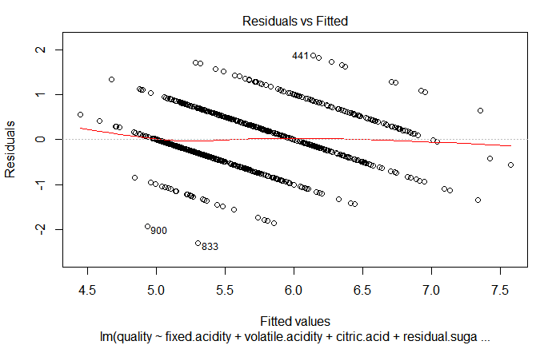

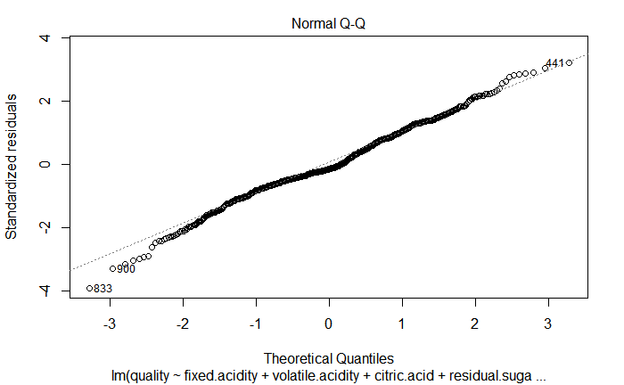

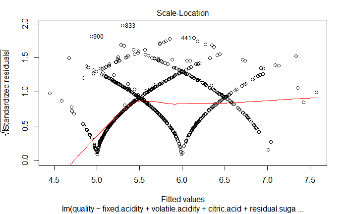

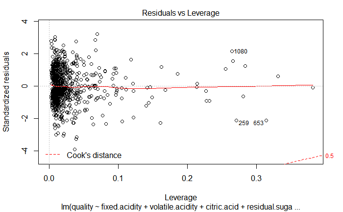

```r
rw_step %>% plot()
```

```r
yhat_step <- predict(rw_step, validation)
RMSE_step <- rmse(y_obs, yhat_step)
df_Step <- data.frame(Method = 'Step', RMSE = RMSE_step)
df_Step
```

| Method | RMSE |
| --- | --- |
| Step | 0.669506 |

## Lasso Regression Model

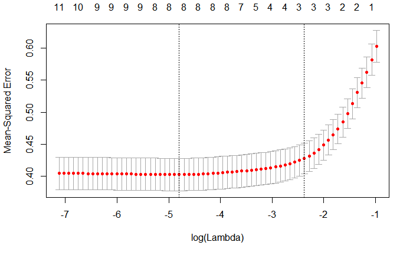

```r
library(glmnet)
training.x <- model.matrix(quality ~ .-1, training)
training.y <- training$quality
rw_lasso <- cv.glmnet(training.x, training.y, alpha = 1.0)
rw_lasso %>% plot()
```

```r
rw_lasso %>% coef(s='lambda.min')
```

```
12 x 1 sparse Matrix of class "dgCMatrix"
                                 1
(Intercept)           19.570045012
fixed.acidity          .
volatile.acidity      -0.926794785
citric.acid            .
residual.sugar         .
chlorides             -0.925196747
free.sulfur.dioxide    0.004261524
total.sulfur.dioxide  -0.002758770
density              -15.616051191
pH                    -0.365281556
sulphates              0.788733828
alcohol                0.283223608
```

```r
rw_lasso %>% coef(s='lambda.1se')
```

```
12 x 1 sparse Matrix of class "dgCMatrix"
                              1
(Intercept)           3.2866545
fixed.acidity         .
volatile.acidity     -0.7301353
citric.acid           .
residual.sugar        .
chlorides             .
free.sulfur.dioxide   .
total.sulfur.dioxide  .
density               .
pH                    .
sulphates             0.2832918
alcohol               0.2440145
```

```r
validation.x <- model.matrix(quality ~ .-1, validation)
yhat_lasso <- predict(rw_lasso, s='lambda.min', newx = validation.x)
RMSE_lasso <- rmse(y_obs, yhat_lasso)
df_Lasso <- data.frame(Method = 'Lasso', RMSE = RMSE_lasso)
df_Lasso
```

| Method | RMSE |
| --- | --- |
| Lasso | 0.6613833 |

## Ridge Regression Model

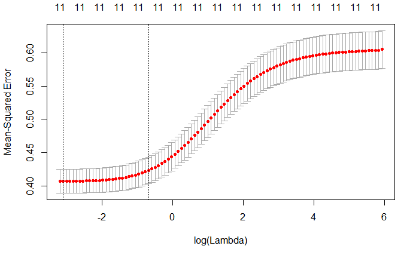

```r
rw_ridge <- cv.glmnet(training.x, training.y, alpha = 0)
rw_ridge %>% plot()
```

```r
rw_ridge %>% coef(s='lambda.min')
```

```
12 x 1 sparse Matrix of class "dgCMatrix"
                                 1
(Intercept)           36.485560769
fixed.acidity          0.012195482
volatile.acidity      -0.898711128
citric.acid           -0.005129857
residual.sugar         0.004911780
chlorides             -1.109867270
free.sulfur.dioxide    0.005421523
total.sulfur.dioxide  -0.003151422
density              -32.496125300
pH                    -0.358859682
sulphates              0.838617631
alcohol                0.258673896
```

```r
rw_ridge %>% coef(s='lambda.1se')
```

```
12 x 1 sparse Matrix of class "dgCMatrix"
                                 1
(Intercept)           42.472252678
fixed.acidity          0.014350912
volatile.acidity      -0.631679840
citric.acid            0.209578810
residual.sugar         0.005736028
chlorides             -0.791573482
free.sulfur.dioxide    0.001334421
total.sulfur.dioxide  -0.001848736
density              -38.451387357
pH                    -0.111171719
sulphates              0.570585101
alcohol                0.168517211
```

```r
yhat_ridge <- predict(rw_ridge, s='lambda.min', newx = validation.x)
RMSE_ridge <- rmse(y_obs, yhat_ridge)
df_Ridge <- data.frame(Method = 'Ridge', RMSE = RMSE_ridge)
df_Ridge
```

| Method | RMSE |
| --- | --- |
| Ridge | 0.6619621 |

Ridge regression model shows RMSE 0.6619621.  
This model cannot reduce features.

## Elastic Net Regression Model

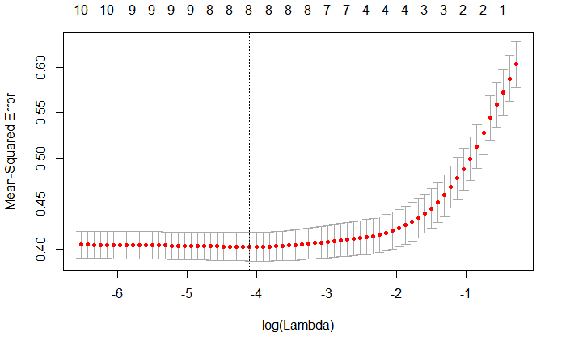

```r
rw_elastic <- cv.glmnet(training.x, training.y, alpha = 0.5)
rw_elastic %>% plot()
```

```r
rw_elastic %>% coef(s='lambda.min')
```

```
12 x 1 sparse Matrix of class "dgCMatrix"
                                 1
(Intercept)           20.257294529
fixed.acidity          .
volatile.acidity      -0.923383239
citric.acid            .
residual.sugar         .
chlorides             -0.917823286
free.sulfur.dioxide    0.004077715
total.sulfur.dioxide  -0.002708415
density              -16.289692203
pH                    -0.359444597
sulphates              0.784395130
alcohol                0.279935382
```

```r
rw_elastic %>% coef(s='lambda.1se')
```

```
12 x 1 sparse Matrix of class "dgCMatrix"
                                 1
(Intercept)           3.1955268231
fixed.acidity         .
volatile.acidity     -0.8181968209
citric.acid           .
residual.sugar        .
chlorides             .
free.sulfur.dioxide   .
total.sulfur.dioxide -0.0005015259
density               .
pH                    .
sulphates             0.4357488414
alcohol               0.2498996456
```

```r
yhat_elastic <- predict(rw_elastic, s='lambda.min', newx = validation.x)
RMSE_elastic <- rmse(y_obs, yhat_elastic)
df_Elastic <- data.frame(Method = 'Elastic', RMSE = RMSE_elastic)
df_Elastic
```

| Method | RMSE |
| --- | --- |
| Elastic | 0.661536 |

Elastic Net regression model shows RMSE 0.661536.

## Decision Tree Model

```r
library(rpart)
rw_dt <- rpart(quality ~ ., training)
rw_dt
```

```
n= 959

node), split, n, deviance, yval
      * denotes terminal node

 1) root 959 578.859200 5.624609
   2) alcohol< 11.55 823 389.662200 5.489672
     4) alcohol< 10.15 484 165.157000 5.297521
       8) volatile.acidity>=0.4175 378 103.642900 5.214286 *
       9) volatile.acidity< 0.4175 106  49.556600 5.594340
        18) sulphates< 0.585 42   9.833333 5.166667 *
        19) sulphates>=0.585 64  27.000000 5.875000 *
     5) alcohol>=10.15 339 181.120900 5.764012
      10) volatile.acidity>=0.405 227 106.105700 5.607930
        20) volatile.acidity>=0.865 18  12.500000 4.833333 *
        21) volatile.acidity< 0.865 209  81.875600 5.674641
          42) free.sulfur.dioxide< 7.5 53  22.188680 5.358491 *
          43) free.sulfur.dioxide>=7.5 156  52.589740 5.782051 *
      11) volatile.acidity< 0.405 112  58.276790 6.080357
        22) chlorides>=0.0875 28  10.107140 5.678571 *
        23) chlorides< 0.0875 84  42.142860 6.214286 *
   3) alcohol>=11.55 136  83.529410 6.441176
     6) sulphates< 0.615 48  25.916670 5.958333 *
     7) sulphates>=0.615 88  40.318180 6.704545 *
```

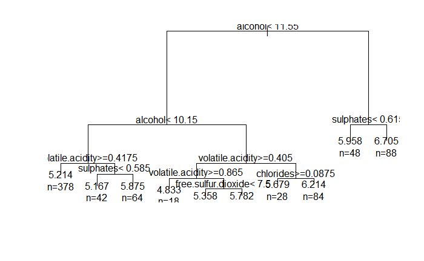

```r
rw_dt %>% plot(); text(rw_dt, use.n = T)
```

```r
yhat_dt <- predict(rw_dt, validation)
RMSE_dt <- rmse(y_obs, yhat_dt)
df_DT <- data.frame(Method = 'DT', RMSE = RMSE_dt)
df_DT
```

| Method | RMSE |
| --- | --- |
| DT | 0.6965824 |

The decision tree model shows RMSE 0.6965824.

## RandomForest Model

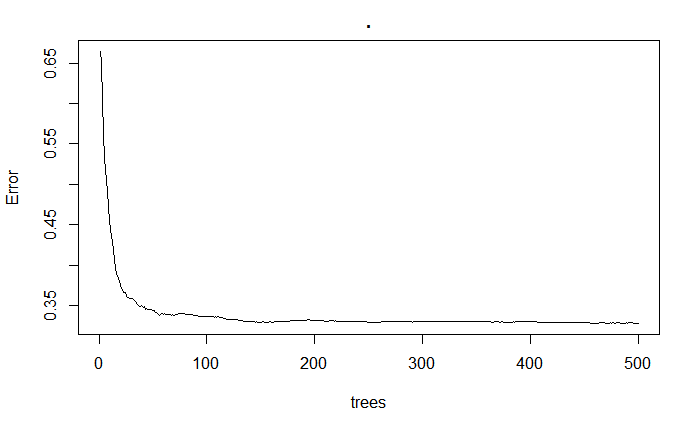

```r
library(randomForest)
set.seed(0417)
rw_rf <- randomForest(quality ~ ., training)
rw_rf %>% plot()
```

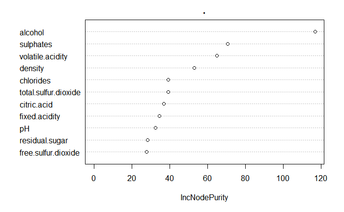

```r
rw_rf %>% varImpPlot()
```

```r
yhat_rf <- predict(rw_rf, newdata = validation)
RMSE_rf <- rmse(y_obs, yhat_rf)
df_RF <- data.frame(Method = 'RF', RMSE = RMSE_rf)
df_RF
```

| Method | RMSE |
| --- | --- |
| RF | 0.5944378 |

The randomforest model shows RMSE 0.5944378.

## Gradient boosting Model

```r
library(gbm)
set.seed(0417)
rw_gbm <- gbm(quality ~ ., data=training, n.trees = 1000, cv.folds = 3, verbose = T)
```

```
Distribution not specified, assuming gaussian ...
```

```r
rw_gbm
```

```
gbm(formula = quality ~ ., data = training, n.trees = 1000, cv.folds = 3,
    verbose = T)
A gradient boosted model with gaussian loss function.
1000 iterations were performed.
The best cross-validation iteration was 282.
There were 11 predictors of which 11 had non-zero influence.
```

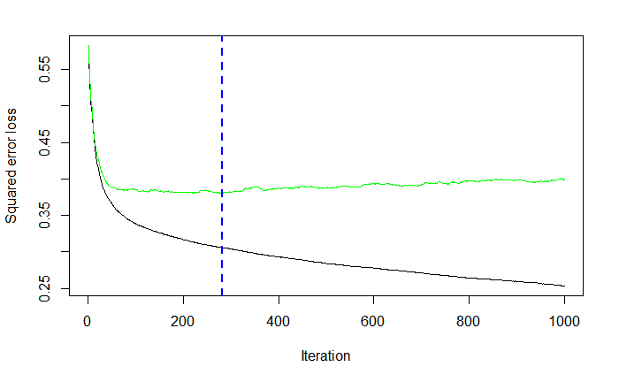

```r
best_iter <- gbm.perf(rw_gbm, method='cv')
```

```r
yhat_gbm <- predict(rw_gbm, n.trees = best_iter, newdata = validation)
RMSE_gbm <- rmse(y_obs, yhat_gbm)
df_GBM <- data.frame(Method = 'GBM', RMSE = RMSE_gbm)
df_GBM
```

| Method | RMSE |
| --- | --- |
| GBM | 0.6339536 |

The gradient boosting model shows RMSE 0.6339536.

## Model selection

```r
df_result <- rbind(df_LM, df_LM2, df_Step, df_Lasso, df_Ridge, df_Elastic, df_DT, df_RF, df_GBM)
df_result[order(df_result$RMSE),]
```

|  | Method | RMSE |
| --- | --- | --- |
| 8 | RF | 0.5944378 |
| 9 | GBM | 0.6339536 |
| 4 | Lasso | 0.6613833 |
| 6 | Elastic | 0.6615360 |
| 5 | Ridge | 0.6619621 |
| 1 | LM | 0.6624028 |
| 2 | LM2 | 0.6645706 |
| 3 | Step | 0.6695060 |
| 7 | DT | 0.6965824 |

The randomforest model has the least LSE(least squared error) in these models.  
I suggest the randomforest model to predict the quality of red wines.

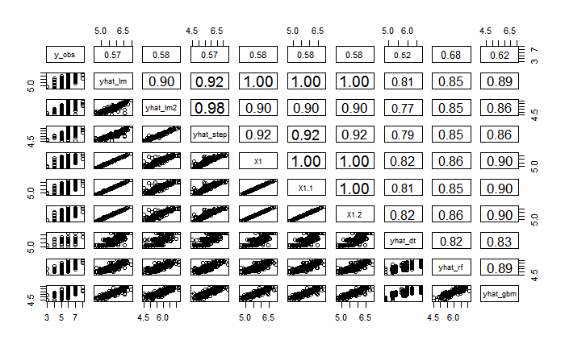

```r
pairs(data.frame(y_obs, yhat_lm, yhat_lm2, yhat_step, yhat_lasso, yhat_ridge, yhat_elastic, yhat_dt, yhat_rf, yhat_gbm), upper.panel = panel.cor)
```

## Model test

```r
y_test <- test$quality
yhat_test <- predict(rw_rf, newdata = test)
rmse(y_test, yhat_test)
```

```
[1] 0.6629703
```

The randomforest model shows RMSE 0.6629703 in test sets.